# Mouse Infinium methylation data processing with RnBeads

Seung June Kim

#### Introduction

The goal is to display some key data frame structures and visuals that you can expect to get from running the code in RnBeads_with_RepeatMasker.R

Using RnBeads dev version (Müller et al. 2019).

#### Setup[^1][^2]

What should RepeatMasker table and $SAMPLE.csv file look like? `sample.table` was created solely for demonstration purposes; it’s not needed to run the code.

```r
head(tab.rmsk)
```

[output not shown]

```r
head(sample.table,14)
```

|  | X.Header. | X | X.1 | X.2 | X.3 | X.4 | X.5 | X.6 | X.7 | X.8 | X.9 |
| --- | --- | --- | --- | --- | --- | --- | --- | --- | --- | --- | --- |
| 1 | Investigator Name |  |  |  |  |  |  |  |  |  |  |
| 2 | Project Name |  |  |  |  |  |  |  |  |  |  |
| 3 | Experiment Name |  |  |  |  |  |  |  |  |  |  |
| 4 | Date | 02-02-2023 |  |  |  |  |  |  |  |  |  |
| 5 | [Manifests] |  |  |  |  |  |  |  |  |  |  |
| 6 | A | MouseMethylation-12v1-0_A2.bpm |  |  |  |  |  |  |  |  |  |
| 7 | [Data] |  |  |  |  |  |  |  |  |  |  |
| 8 | Sample_Name | Sample_Well | Sample_Plate | Sample_Group | Pool_ID | Sentrix_ID | Sentrix_Position | Sample_Type | Sample_Treatment | Sample_Replicate | Sample_Identity |
| 9 | B1 DMSO | A01 | PAS23023 |  | 0 | 205832350006 | R01C01 | B | D | 1 | B_D |
| 10 | NB1 DMSO | C01 | PAS23023 |  | 0 | 205832350006 | R03C01 | NB | D | 1 | NB_D |

[output cut: 4 more lines]

#### Interesting but confusing functions

`get.table()` returns a useful, unsorted data frame of statistics for each $ANNOTATION probe(rows) from `diffmeth.\$ANNOTATION` S4 object. `annotation()` returns row-matching annotation for each probe in tab.$ANNOTATION.

```r
diffmeth.rmsk <- rnb.execute.computeDiffMeth(rnb.set, cmp.cols, region.types="rmsk")
tab.rmsk <- get.table(diffmeth.rmsk,comparison, region.type="rmsk",return.data.frame=T)
aa.rmsk <- annotation(rnb.set,type="rmsk")
```

```r
head(tab.rmsk)
```

|  | mean.mean.g1 | mean.mean.g2 | mean.mean.diff | mean.mean.quot.log2 | comb.p.val | comb.p.adj.fdr | num.sites | mean.num.na.g1 | mean.num.na.g2 | mean.mean.covg.g1 | mean.mean.covg.g2 | mean.nsamples.covg.thresh.g1 | mean.nsamples.covg.thresh.g2 | combinedRank |
| --- | --- | --- | --- | --- | --- | --- | --- | --- | --- | --- | --- | --- | --- | --- |
| 1 | 0.7539077 | 0.7713189 | -0.017411198 | -0.032513175 | 0.1091943 | 0.4557239 | 1 | 0 | 0 | 22.33333 | 25.00000 | 3 | 3 | 6985 |
| 2 | 0.8585011 | 0.8533401 | 0.005160963 | 0.008598615 | 0.5222993 | 0.8408950 | 1 | 0 | 0 | 27.66667 | 20.00000 | 3 | 3 | 18576 |
| 3 | 0.8657933 | 0.8744245 | -0.008631208 | -0.014148592 | 0.2042860 | 0.6075644 | 1 | 0 | 0 | 24.66667 | 24.33333 | 3 | 3 | 13776 |
| 4 | 0.7520166 | 0.7590930 | -0.007076353 | -0.013335547 | 0.6216694 | 0.8860324 | 1 | 0 | 0 | 23.66667 | 23.33333 | 3 | 3 | 20454 |
| 5 | 0.8108180 | 0.8189176 | -0.008099642 | -0.014166401 | 0.4723224 | 0.8144906 | 1 | 0 | 0 | 19.00000 | 19.33333 | 3 | 3 | 16904 |
| 6 | 0.8954512 | 0.8973859 | -0.001934682 | -0.003079324 | 0.7580065 | 0.9374626 | 1 | 0 | 0 | 25.66667 | 29.33333 | 3 | 3 | 25046 |

```r
head(aa.rmsk)
```

|  | Chromosome | Start | End | Strand | name |
| --- | --- | --- | --- | --- | --- |
| 699 | chr1 | 3035552 | 3035969 | * | LTR |
| 843 | chr1 | 3121629 | 3121965 | * | LTR |
| 1368 | chr1 | 3469565 | 3469891 | * | LTR |
| 2176 | chr1 | 3984251 | 3985340 | * | LTR |
| 2489 | chr1 | 4208633 | 4209515 | * | LINE |
| 3132 | chr1 | 4584673 | 4585628 | * | LINE |

These two data frames are bound together.

```r
annotated.tab.rmsk <- data.frame(tab.rmsk,aa.rmsk, row.names=NULL)
head(annotated.tab.rmsk)
```

|  | mean.mean.g1 | mean.mean.g2 | mean.mean.diff | mean.mean.quot.log2 | comb.p.val | comb.p.adj.fdr | num.sites | mean.num.na.g1 | mean.num.na.g2 | mean.mean.covg.g1 | mean.mean.covg.g2 | mean.nsamples.covg.thresh.g1 | mean.nsamples.covg.thresh.g2 | combinedRank | Chromosome | Start | End | Strand | name |
| --- | --- | --- | --- | --- | --- | --- | --- | --- | --- | --- | --- | --- | --- | --- | --- | --- | --- | --- | --- |
| 1 | 0.7539077 | 0.7713189 | -0.017411198 | -0.032513175 | 0.1091943 | 0.4557239 | 1 | 0 | 0 | 22.33333 | 25.00000 | 3 | 3 | 6985 | chr1 | 3035552 | 3035969 | * | LTR |
| 2 | 0.8585011 | 0.8533401 | 0.005160963 | 0.008598615 | 0.5222993 | 0.8408950 | 1 | 0 | 0 | 27.66667 | 20.00000 | 3 | 3 | 18576 | chr1 | 3121629 | 3121965 | * | LTR |
| 3 | 0.8657933 | 0.8744245 | -0.008631208 | -0.014148592 | 0.2042860 | 0.6075644 | 1 | 0 | 0 | 24.66667 | 24.33333 | 3 | 3 | 13776 | chr1 | 3469565 | 3469891 | * | LTR |
| 4 | 0.7520166 | 0.7590930 | -0.007076353 | -0.013335547 | 0.6216694 | 0.8860324 | 1 | 0 | 0 | 23.66667 | 23.33333 | 3 | 3 | 20454 | chr1 | 3984251 | 3985340 | * | LTR |
| 5 | 0.8108180 | 0.8189176 | -0.008099642 | -0.014166401 | 0.4723224 | 0.8144906 | 1 | 0 | 0 | 19.00000 | 19.33333 | 3 | 3 | 16904 | chr1 | 4208633 | 4209515 | * | LINE |
| 6 | 0.8954512 | 0.8973859 | -0.001934682 | -0.003079324 | 0.7580065 | 0.9374626 | 1 | 0 | 0 | 25.66667 | 29.33333 | 3 | 3 | 25046 | chr1 | 4584673 | 4585628 | * | LINE |

Order the rows by “combinedRank”. The rownames of the `annotated.tab.\$ANNOTATION.order` data frame refers to the original row numbers of the annotated.tab.sites data frame, which is not ordered.

```r
annotated.tab.rmsk.order <- annotated.tab.rmsk[order(annotated.tab.rmsk[,"combinedRank"]),]
head(annotated.tab.rmsk.order,3)
```

|  | mean.mean.g1 | mean.mean.g2 | mean.mean.diff | mean.mean.quot.log2 | comb.p.val | comb.p.adj.fdr | num.sites | mean.num.na.g1 | mean.num.na.g2 | mean.mean.covg.g1 | mean.mean.covg.g2 | mean.nsamples.covg.thresh.g1 | mean.nsamples.covg.thresh.g2 | combinedRank | Chromosome | Start | End | Strand | name |
| --- | --- | --- | --- | --- | --- | --- | --- | --- | --- | --- | --- | --- | --- | --- | --- | --- | --- | --- | --- |
| 12842 | 0.1096282 | 0.5779636 | -0.4683353 | -2.297169 | 2.902269e-13 | 1.031741e-09 | 1 | 0 | 0 | 24.00000 | 28.33333 | 3 | 3 | 4 | chr7 | 110920614 | 110920788 | * | SINE |
| 2839 | 0.1322201 | 0.4972435 | -0.3650233 | -1.842680 | 3.274019e-14 | 9.113735e-10 | 2 | 0 | 0 | 21.16667 | 28.00000 | 3 | 3 | 14 | chr2 | 90676949 | 90677308 | * | LINE |
| 22365 | 0.1141823 | 0.4741471 | -0.3599648 | -1.962986 | 6.936504e-13 | 1.103012e-09 | 1 | 0 | 0 | 21.00000 | 20.00000 | 3 | 3 | 17 | chr13 | 102691299 | 102691567 | * | LINE |

```r
rownames(annotated.tab.rmsk.order)[1:10]
```

```
##  [1] "12842" "2839"  "22365" "24294" "6831"  "20269" "17342" "17343" "7604"  "8467"
```

`annotated.tab.\$ANNOTATION.order` data frame does not contain any information about beta values. These are extracted from rnb.set using `meth()`, annotation name, and row index from `annotated.tab.\$ANNOTATION.order`.

```r
topDiffBeta.rmsk.full <- meth(rnb.set.full, type="rmsk")[as.integer(rownames(annotated.tab.rmsk.order)),]
```

#### Heatmap(s)

Differentially methylated probes annotated with RepeatMasker

[output not shown]

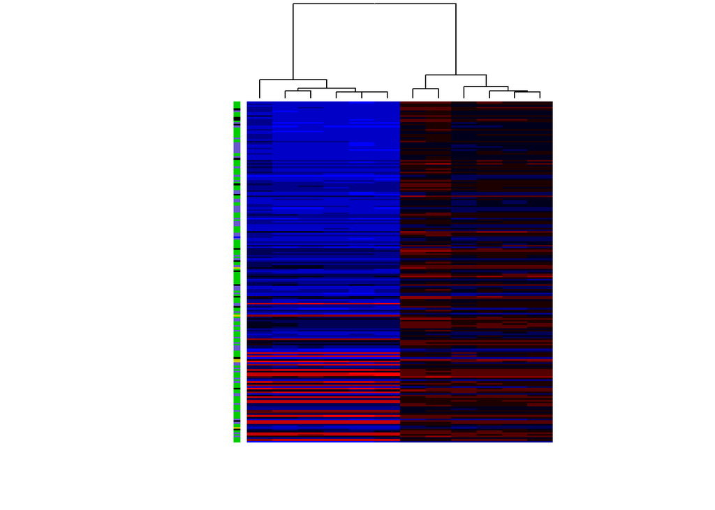

```r
colSide <- annotated.tab.rmsk.order$name

colSide <-gsub("LTR","slateblue3",colSide)
colSide <- gsub("LINE","green3",colSide)
colSide <- gsub("SINE","green3",colSide)
colSide <- gsub("DNA","black",colSide)
colSide <- gsub("Simple_repeat","yellow3",colSide)
colSide <- gsub("Other","blue",colSide)
colSide <- gsub("Unknown","blue",colSide)

par(font=2, font.axis=2, font.lab=2,cex.lab=1.5, cex.axis=1.5, lty=1)
heatmap.2(topDiffBeta.rmsk.full[1:200,c(1,5,9,2,6,10,3,7,11,4,8,12)],
          col=colfunc(10), scale="none", Rowv=F, Colv=T,
          cexCol=1, labCol=NA, labRow=NA,srtCol=0, adjCol=c(0.5,0),
          density.info = "none",trace="none", dendrogram = "column",
          symkey=FALSE,symbreaks=F,revC = FALSE, RowSideColors = colSide[1:200],
          breaks=c(0.0,0.1,0.2,0.3,0.4,0.5,0.6,0.7,0.8,0.9,1),
          lmat=rbind(c(5,0,4),c(3,1,2)),
          lhei=c(1,4),
          lwid=c(1.75,0.1, 3.5),margins=c(5,12),cexRow=1.2)
```

Müller, Fabian, Michael Scherer, Yassen Assenov, Pavlo Lutsik, Jörn Walter, Thomas Lengauer, and Christoph Bock. 2019. “RnBeads 2.0: Comprehensive Analysis of DNA Methylation Data.” *Genome Biology* 20 (1): 55. https://doi.org/10.1186/s13059-019-1664-9.

[^1]: Run rmarkdown::render(“RnBeads_with_RepeatMasker.Rmd”) in the same workspace as .R to avoid worrying about global environment.
[^2]: rnb.set object is not stored well in the global environment. If there are errors, re-run the script from top to bottom (remove output folders “result” and “resultFull”). There is a way to write theses objects to disk instead of RAM, but I didn’t want to lose any disk space.